# Self-Driving Car Engineer Nanodegree

### Project Writeup

Once you have completed the code implementation, document your results in a project writeup using this [template](https://github.com/udacity/CarND-Traffic-Sign-Classifier-Project/blob/master/writeup_template.md) as a guide. The writeup can be in a markdown or pdf file.

## Step 4 (Optional): Visualize the Neural Network's State with Test Images

This Section is not required to complete but acts as an additional excersise for understaning the output of a neural network's weights. While neural networks can be a great learning device they are often referred to as a black box. We can understand what the weights of a neural network look like better by plotting their feature maps. After successfully training your neural network you can see what it's feature maps look like by plotting the output of the network's weight layers in response to a test stimuli image. From these plotted feature maps, it's possible to see what characteristics of an image the network finds interesting. For a sign, maybe the inner network feature maps react with high activation to the sign's boundary outline or to the contrast in the sign's painted symbol.

Provided for you below is the function code that allows you to get the visualization output of any tensorflow weight layer you want. The inputs to the function should be a stimuli image, one used during training or a new one you provided, and then the tensorflow variable name that represents the layer's state during the training process, for instance if you wanted to see what the LeNet lab's feature maps looked like for it's second convolutional layer you could enter conv2 as the tf_activation variable.

For an example of what feature map outputs look like, check out NVIDIA's results in their paper [End-to-End Deep Learning for Self-Driving Cars](https://devblogs.nvidia.com/parallelforall/deep-learning-self-driving-cars/) in the section Visualization of internal CNN State. NVIDIA was able to show that their network's inner weights had high activations to road boundary lines by comparing feature maps from an image with a clear path to one without. Try experimenting with a similar test to show that your trained network's weights are looking for interesting features, whether it's looking at differences in feature maps from images with or without a sign, or even what feature maps look like in a trained network vs a completely untrained one on the same sign image.

[figure not shown]

Your output should look something like this (above)

```python
def visualize_convolution_output(sess, layer_tensor, X_data, title, **imshow_options):
    activation = sess.run(layer_tensor, feed_dict={x_placeholder: X_data})

    activation = activation[0] # visualize for just the first input.

    num_fms = activation.shape[-1]

    fig, axes = plt.subplots(ncols=num_fms, figsize=(10, 1))
    fig.suptitle(title)

    for fm_ind, ax in zip(range(num_fms), axes):
        ax.imshow(activation[:,:,fm_ind], cmap='gray')
        ax.get_xaxis().set_visible(False)
        ax.get_yaxis().set_visible(False)

def visualize_convolution_outputs(X_datum):
    with tf.Session() as sess:
        saver.restore(sess, best_sess_checkpoint)

        X_data = [X_datum] # a batch of one input.

        conv_layers = all_layers[0:2] # two conv layers

        titles = ['layer {}'.format(i + 1) for i in range(len(conv_layers))]

        for layer, title in zip(conv_layers, titles):
            visualize_convolution_output(sess, layer, X_data, title)
```

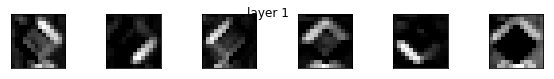

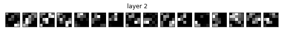

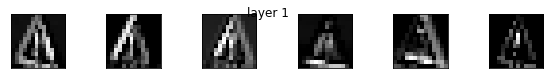

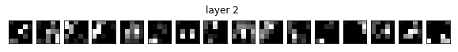

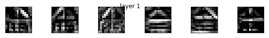

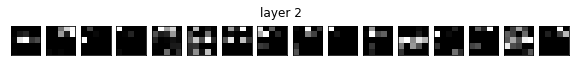

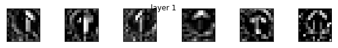

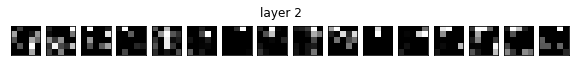

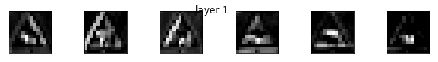

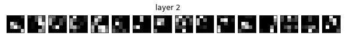

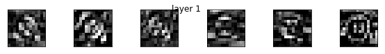

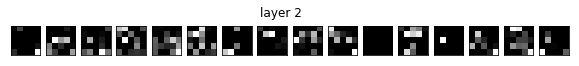

[10 more figures not shown]

```python
visualize_convolution_outputs(reference_images[12])
for X_datum in X_test_extra_pp:
    visualize_convolution_outputs(X_datum)
```

```python
def visualize_feature_map(sess, weight_tensor, title, **imshow_options):
    fms = sess.run(weight_tensor)

    # numbers of output and input feature maps
    num_fm_in = fms.shape[-2]
    num_fm_out = fms.shape[-1]

    fig, axes = plt.subplots(nrows=num_fm_in, ncols=num_fm_out, figsize=(10, 5))
    axes = axes.reshape(num_fm_in, num_fm_out) # force 2d when num rows or num cols is 1
    fig.suptitle(title)

    for fmi in range(num_fm_in):
        for fmo in range(num_fm_out):
            ax = axes[fmi][fmo]
            ax.imshow(fms[:,:,fmi,fmo], interpolation="nearest", cmap="gray", **imshow_options)
            ax.get_xaxis().set_visible(False)
            ax.get_yaxis().set_visible(False)

def visualize_feature_maps():
    with tf.Session() as sess:
        saver.restore(sess, best_sess_checkpoint)

        conv_weights = all_weights[0:2] # two conv layers

        titles = ['layer {}'.format(i + 1) for i in range(len(conv_weights))]

        for w, title in zip(conv_weights, titles):
            visualize_feature_map(sess, w, title)
```

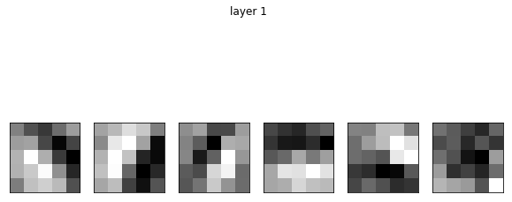

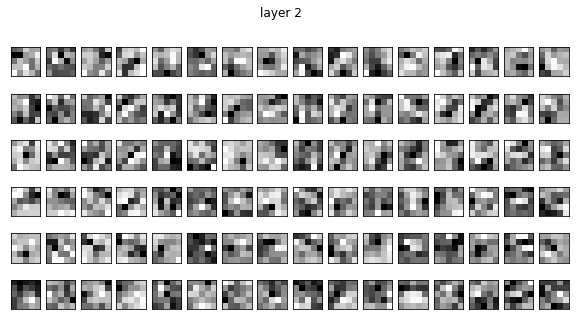

```python
visualize_feature_maps()
```